# Bias_Variance_TTS slides

## Starting off

Define write down a definition for the following two terms:

Bias -

Variance -

# Understanding the Machine Learning Process

Agenda:

- Bias versus Variance
- Train Test Split
- Model Evaluation

## The Machine Learning Process

1. Look at the big picture.
2. Get the data.
3. Discover and visualize the data to gain insights.
4. Prepare the data for Machine Learning algorithms.
5. Select a model and train it.
6. Fine-tune your model.
7. Present your solution.
8. Launch, monitor, and maintain your system.

**A proper machine learning workflow includes:**

- Separate training and test sets
- Trying appropriate algorithms (No Free Lunch)
- Fitting model parameters
- Tuning impactful hyperparameters
- Proper performance metrics
- Systematic cross-validation

# Bias - Variance

There are 3 types of prediction error: bias, variance, and irreducible error.

**Total Error = Bias + Variance + Irreducible Error**

### The Bias-Variance Tradeoff

**Let's do a thought experiment:**

1. Imagine you've collected 5 different training sets for the same problem.
2. Now imagine using one algorithm to train 5 models, one for each of your training sets.
3. Bias vs. variance refers to the accuracy vs. consistency of the models trained by your algorithm.

[figure not shown]

**High bias** algorithms tend to be less complex, with simple or rigid underlying structure.

- They train models that are consistent, but inaccurate on average.
- These include linear or parametric algorithms such as regression and naive Bayes.

On the other hand, **high variance** algorithms tend to be more complex, with flexible underlying structure.

- They train models that are accurate on average, but inconsistent.
- These include non-linear or non-parametric algorithms such as decision trees and nearest neighbors.

### Bias-Variance Tradeoff

This tradeoff in complexity is why there's a tradeoff in bias and variance - an algorithm cannot simultaneously be more complex and less complex.

**Total Error = Bias^2 + Variance + Irreducible Error**

[figure not shown]

### Error from Bias

**Bias** is the difference between your model's expected predictions and the true values.

[figure not shown]

### Error from Variance

**Variance** refers to your algorithm's sensitivity to specific sets of training data.

[figure not shown]

Which one is overfit and which one is underfit?

We want to try to find the proper balance of variance and bias

[figure not shown]

# Train Test Split

**How do we know if our model is overfitting or underfitting?**

If our model is not performing well on the training data, we are probably underfitting it.

To know if our model is overfitting the data, we need to test our model on unseen data. We then measure our performance on the unseen data.

If the model performs way worse on the unseen data, it is probably overfitting the data.

The previous module introduced the idea of dividing your data set into two subsets:

- **training set** —a subset to train a model.
- **test set**—a subset to test the trained model.

You could imagine slicing the single data set as follows:

[figure not shown]

**Never train on test data.** If you are seeing surprisingly good results on your evaluation metrics, it might be a sign that you are accidentally training on the test set.

[figure not shown]

## Model Evaluation Metrics for Regression

**Mean Absolute Error** (MAE) is the mean of the absolute value of the errors:

[figure not shown]

**Mean Squared Error** (MSE) is the mean of the squared errors:

[figure not shown]

**Root Mean Squared Error (RMSE)** is the square root of the mean of the squared errors:

[figure not shown]

MSE is more popular than MAE because MSE "punishes" larger errors.

But, RMSE is even more popular than MSE because RMSE is interpretable in the "y" units.

Additionally, I like to divide the RMSE by the standard deviation to convert it to something similiar to a Z-Score.

# Practicum

```python
import pandas as pd
import numpy as np
from matplotlib import pyplot as plt
%matplotlib
import seaborn as sns
```

```
Using matplotlib backend: Qt5Agg
```

### Read in Kings County Housing Data Set

```python
df = pd.read_csv('kc_house_data.csv',index_col='id')
```

### Take a look at the data

```python
df.head(10)
```

| id | date | price | bedrooms | bathrooms | sqft_living | sqft_lot | floors | waterfront | view | condition | grade | sqft_above | sqft_basement | yr_built | yr_renovated | zipcode | lat | long | sqft_living15 | sqft_lot15 |
| --- | --- | --- | --- | --- | --- | --- | --- | --- | --- | --- | --- | --- | --- | --- | --- | --- | --- | --- | --- | --- |
| 7129300520 | 20141013T000000 | 221900.0 | 3 | 1.00 | 1180 | 5650 | 1.0 | 0 | 0 | 3 | 7 | 1180 | 0 | 1955 | 0 | 98178 | 47.5112 | -122.257 | 1340 | 5650 |
| 6414100192 | 20141209T000000 | 538000.0 | 3 | 2.25 | 2570 | 7242 | 2.0 | 0 | 0 | 3 | 7 | 2170 | 400 | 1951 | 1991 | 98125 | 47.7210 | -122.319 | 1690 | 7639 |
| 5631500400 | 20150225T000000 | 180000.0 | 2 | 1.00 | 770 | 10000 | 1.0 | 0 | 0 | 3 | 6 | 770 | 0 | 1933 | 0 | 98028 | 47.7379 | -122.233 | 2720 | 8062 |
| 2487200875 | 20141209T000000 | 604000.0 | 4 | 3.00 | 1960 | 5000 | 1.0 | 0 | 0 | 5 | 7 | 1050 | 910 | 1965 | 0 | 98136 | 47.5208 | -122.393 | 1360 | 5000 |
| 1954400510 | 20150218T000000 | 510000.0 | 3 | 2.00 | 1680 | 8080 | 1.0 | 0 | 0 | 3 | 8 | 1680 | 0 | 1987 | 0 | 98074 | 47.6168 | -122.045 | 1800 | 7503 |
| 7237550310 | 20140512T000000 | 1225000.0 | 4 | 4.50 | 5420 | 101930 | 1.0 | 0 | 0 | 3 | 11 | 3890 | 1530 | 2001 | 0 | 98053 | 47.6561 | -122.005 | 4760 | 101930 |
| 1321400060 | 20140627T000000 | 257500.0 | 3 | 2.25 | 1715 | 6819 | 2.0 | 0 | 0 | 3 | 7 | 1715 | 0 | 1995 | 0 | 98003 | 47.3097 | -122.327 | 2238 | 6819 |
| 2008000270 | 20150115T000000 | 291850.0 | 3 | 1.50 | 1060 | 9711 | 1.0 | 0 | 0 | 3 | 7 | 1060 | 0 | 1963 | 0 | 98198 | 47.4095 | -122.315 | 1650 | 9711 |
| 2414600126 | 20150415T000000 | 229500.0 | 3 | 1.00 | 1780 | 7470 | 1.0 | 0 | 0 | 3 | 7 | 1050 | 730 | 1960 | 0 | 98146 | 47.5123 | -122.337 | 1780 | 8113 |
| 3793500160 | 20150312T000000 | 323000.0 | 3 | 2.50 | 1890 | 6560 | 2.0 | 0 | 0 | 3 | 7 | 1890 | 0 | 2003 | 0 | 98038 | 47.3684 | -122.031 | 2390 | 7570 |

```python
df['yr_old']=2017 - df['yr_built']

df.drop(['yr_built', 'lat', 'long'], axis=1, inplace=True)
```

```python
df.describe()
```

|  | price | bedrooms | bathrooms | sqft_living | sqft_lot | floors | waterfront | view | condition | grade | sqft_above | sqft_basement | yr_renovated | zipcode | sqft_living15 | sqft_lot15 | yr_old |
| --- | --- | --- | --- | --- | --- | --- | --- | --- | --- | --- | --- | --- | --- | --- | --- | --- | --- |
| count | 2.161300e+04 | 21613.000000 | 21613.000000 | 21613.000000 | 2.161300e+04 | 21613.000000 | 21613.000000 | 21613.000000 | 21613.000000 | 21613.000000 | 21613.000000 | 21613.000000 | 21613.000000 | 21613.000000 | 21613.000000 | 21613.000000 | 21613.000000 |
| mean | 5.400881e+05 | 3.370842 | 2.114757 | 2079.899736 | 1.510697e+04 | 1.494309 | 0.007542 | 0.234303 | 3.409430 | 7.656873 | 1788.390691 | 291.509045 | 84.402258 | 98077.939805 | 1986.552492 | 12768.455652 | 45.994864 |
| std | 3.671272e+05 | 0.930062 | 0.770163 | 918.440897 | 4.142051e+04 | 0.539989 | 0.086517 | 0.766318 | 0.650743 | 1.175459 | 828.090978 | 442.575043 | 401.679240 | 53.505026 | 685.391304 | 27304.179631 | 29.373411 |
| min | 7.500000e+04 | 0.000000 | 0.000000 | 290.000000 | 5.200000e+02 | 1.000000 | 0.000000 | 0.000000 | 1.000000 | 1.000000 | 290.000000 | 0.000000 | 0.000000 | 98001.000000 | 399.000000 | 651.000000 | 2.000000 |
| 25% | 3.219500e+05 | 3.000000 | 1.750000 | 1427.000000 | 5.040000e+03 | 1.000000 | 0.000000 | 0.000000 | 3.000000 | 7.000000 | 1190.000000 | 0.000000 | 0.000000 | 98033.000000 | 1490.000000 | 5100.000000 | 20.000000 |
| 50% | 4.500000e+05 | 3.000000 | 2.250000 | 1910.000000 | 7.618000e+03 | 1.500000 | 0.000000 | 0.000000 | 3.000000 | 7.000000 | 1560.000000 | 0.000000 | 0.000000 | 98065.000000 | 1840.000000 | 7620.000000 | 42.000000 |
| 75% | 6.450000e+05 | 4.000000 | 2.500000 | 2550.000000 | 1.068800e+04 | 2.000000 | 0.000000 | 0.000000 | 4.000000 | 8.000000 | 2210.000000 | 560.000000 | 0.000000 | 98118.000000 | 2360.000000 | 10083.000000 | 66.000000 |
| max | 7.700000e+06 | 33.000000 | 8.000000 | 13540.000000 | 1.651359e+06 | 3.500000 | 1.000000 | 4.000000 | 5.000000 | 13.000000 | 9410.000000 | 4820.000000 | 2015.000000 | 98199.000000 | 6210.000000 | 871200.000000 | 117.000000 |

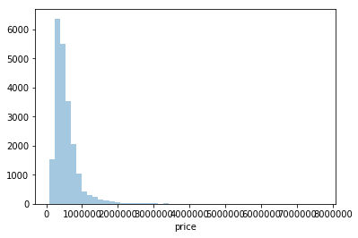

```python
sns.distplot(df.price, bins=50, kde=False);
```

## Feature exploration¶

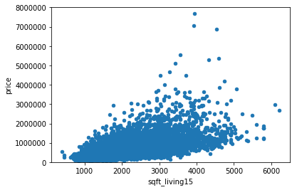

```python
var = 'sqft_living15'
data = pd.concat([df['price'], df[var]], axis=1)
data.plot.scatter(x=var, y='price', ylim=(3,8000000));
```

```python
def  draw_boxplots(var):
    f, ax = plt.subplots(figsize=(12, 6))
    fig = sns.boxplot(x=var, y="price", data=df)
    fig.axis(ymin=0, ymax=3500000);
```

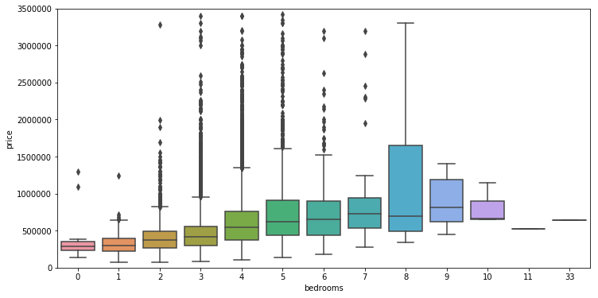

```python
draw_boxplots('bedrooms')
```

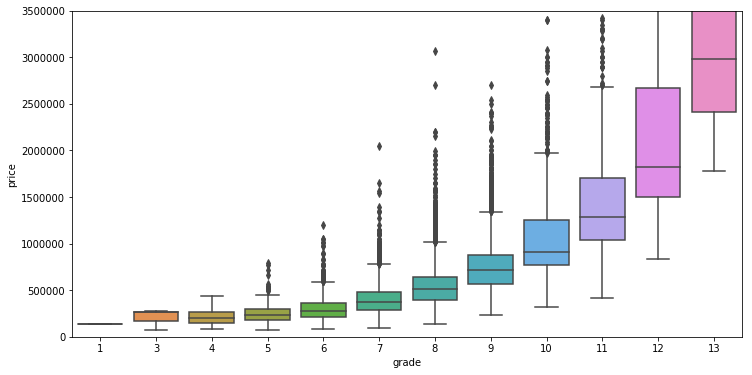

```python
draw_boxplots('grade')
```

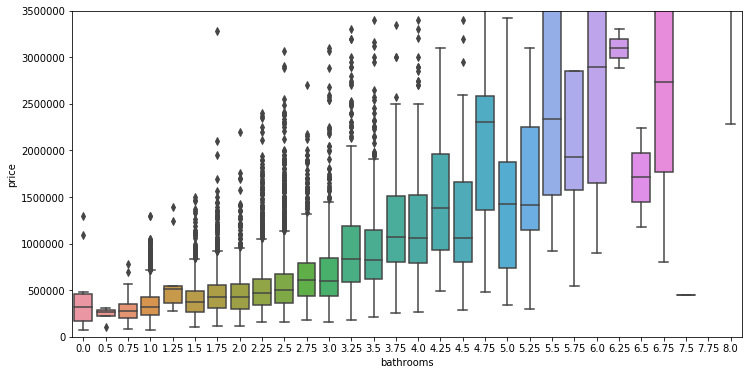

```python
draw_boxplots('bathrooms')
```

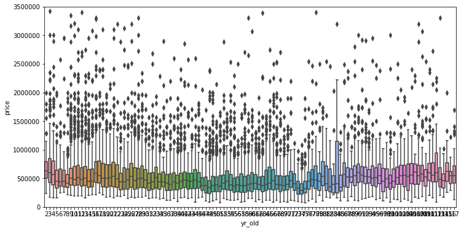

```python
draw_boxplots('yr_old')
```

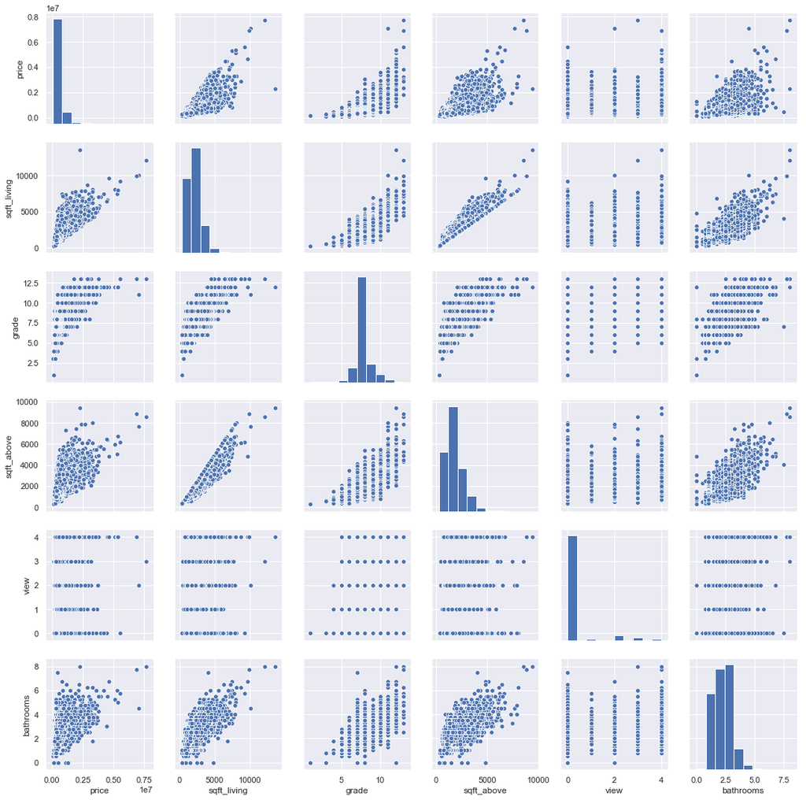

```python
#scatterplot
sns.set()
cols = ['price', 'sqft_living', 'grade', 'sqft_above', 'view', 'bathrooms']
sns.pairplot(df[cols], size = 2.5)
plt.show();
```

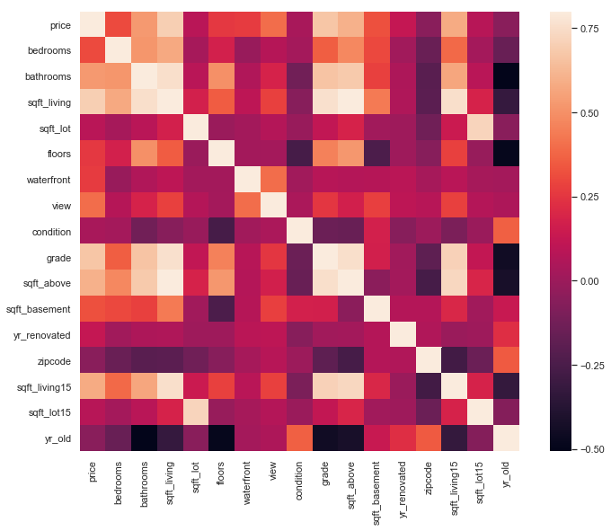

```python
#correlation matrix
corrmat = df.corr()
f, ax = plt.subplots(figsize=(12, 9))
sns.heatmap(corrmat, vmax=.8, square=True)
```

```python
#missing data
total = df.isnull().sum().sort_values(ascending=False)
percent = (df.isnull().sum()/df.isnull().count()).sort_values(ascending=False)
missing_data = pd.concat([total, percent], axis=1, keys=['Total', 'Percent'])
missing_data.head(20)
```

|  | Total | Percent |
| --- | --- | --- |
| yr_old | 0 | 0.0 |
| sqft_lot15 | 0 | 0.0 |
| price | 0 | 0.0 |
| bedrooms | 0 | 0.0 |
| bathrooms | 0 | 0.0 |
| sqft_living | 0 | 0.0 |
| sqft_lot | 0 | 0.0 |
| floors | 0 | 0.0 |
| waterfront | 0 | 0.0 |
| view | 0 | 0.0 |
| condition | 0 | 0.0 |
| grade | 0 | 0.0 |
| sqft_above | 0 | 0.0 |
| sqft_basement | 0 | 0.0 |
| yr_renovated | 0 | 0.0 |
| zipcode | 0 | 0.0 |
| sqft_living15 | 0 | 0.0 |
| date | 0 | 0.0 |

### Identify my features and target variable

```python
target = df.price

#Date  is not in the correct format so we are dropping it for now.
features = df.drop(['price','date'], axis=1)
```

```python
features
```

| id | bedrooms | bathrooms | sqft_living | sqft_lot | floors | waterfront | view | condition | grade | sqft_above | sqft_basement | yr_renovated | zipcode | sqft_living15 | sqft_lot15 | yr_old |
| --- | --- | --- | --- | --- | --- | --- | --- | --- | --- | --- | --- | --- | --- | --- | --- | --- |
| 7129300520 | 3 | 1.00 | 1180 | 5650 | 1.0 | 0 | 0 | 3 | 7 | 1180 | 0 | 0 | 98178 | 1340 | 5650 | 62 |
| 6414100192 | 3 | 2.25 | 2570 | 7242 | 2.0 | 0 | 0 | 3 | 7 | 2170 | 400 | 1991 | 98125 | 1690 | 7639 | 66 |
| 5631500400 | 2 | 1.00 | 770 | 10000 | 1.0 | 0 | 0 | 3 | 6 | 770 | 0 | 0 | 98028 | 2720 | 8062 | 84 |
| 2487200875 | 4 | 3.00 | 1960 | 5000 | 1.0 | 0 | 0 | 5 | 7 | 1050 | 910 | 0 | 98136 | 1360 | 5000 | 52 |
| 1954400510 | 3 | 2.00 | 1680 | 8080 | 1.0 | 0 | 0 | 3 | 8 | 1680 | 0 | 0 | 98074 | 1800 | 7503 | 30 |
| 7237550310 | 4 | 4.50 | 5420 | 101930 | 1.0 | 0 | 0 | 3 | 11 | 3890 | 1530 | 0 | 98053 | 4760 | 101930 | 16 |
| 1321400060 | 3 | 2.25 | 1715 | 6819 | 2.0 | 0 | 0 | 3 | 7 | 1715 | 0 | 0 | 98003 | 2238 | 6819 | 22 |
| 2008000270 | 3 | 1.50 | 1060 | 9711 | 1.0 | 0 | 0 | 3 | 7 | 1060 | 0 | 0 | 98198 | 1650 | 9711 | 54 |
| 2414600126 | 3 | 1.00 | 1780 | 7470 | 1.0 | 0 | 0 | 3 | 7 | 1050 | 730 | 0 | 98146 | 1780 | 8113 | 57 |
| 3793500160 | 3 | 2.50 | 1890 | 6560 | 2.0 | 0 | 0 | 3 | 7 | 1890 | 0 | 0 | 98038 | 2390 | 7570 | 14 |
| 1736800520 | 3 | 2.50 | 3560 | 9796 | 1.0 | 0 | 0 | 3 | 8 | 1860 | 1700 | 0 | 98007 | 2210 | 8925 | 52 |
| 9212900260 | 2 | 1.00 | 1160 | 6000 | 1.0 | 0 | 0 | 4 | 7 | 860 | 300 | 0 | 98115 | 1330 | 6000 | 75 |
| 114101516 | 3 | 1.00 | 1430 | 19901 | 1.5 | 0 | 0 | 4 | 7 | 1430 | 0 | 0 | 98028 | 1780 | 12697 | 90 |
| 6054650070 | 3 | 1.75 | 1370 | 9680 | 1.0 | 0 | 0 | 4 | 7 | 1370 | 0 | 0 | 98074 | 1370 | 10208 | 40 |
| 1175000570 | 5 | 2.00 | 1810 | 4850 | 1.5 | 0 | 0 | 3 | 7 | 1810 | 0 | 0 | 98107 | 1360 | 4850 | 117 |
| 9297300055 | 4 | 3.00 | 2950 | 5000 | 2.0 | 0 | 3 | 3 | 9 | 1980 | 970 | 0 | 98126 | 2140 | 4000 | 38 |
| 1875500060 | 3 | 2.00 | 1890 | 14040 | 2.0 | 0 | 0 | 3 | 7 | 1890 | 0 | 0 | 98019 | 1890 | 14018 | 23 |
| 6865200140 | 4 | 1.00 | 1600 | 4300 | 1.5 | 0 | 0 | 4 | 7 | 1600 | 0 | 0 | 98103 | 1610 | 4300 | 101 |
| 16000397 | 2 | 1.00 | 1200 | 9850 | 1.0 | 0 | 0 | 4 | 7 | 1200 | 0 | 0 | 98002 | 1060 | 5095 | 96 |
| 7983200060 | 3 | 1.00 | 1250 | 9774 | 1.0 | 0 | 0 | 4 | 7 | 1250 | 0 | 0 | 98003 | 1280 | 8850 | 48 |
| 6300500875 | 4 | 1.75 | 1620 | 4980 | 1.0 | 0 | 0 | 4 | 7 | 860 | 760 | 0 | 98133 | 1400 | 4980 | 70 |
| 2524049179 | 3 | 2.75 | 3050 | 44867 | 1.0 | 0 | 4 | 3 | 9 | 2330 | 720 | 0 | 98040 | 4110 | 20336 | 49 |
| 7137970340 | 5 | 2.50 | 2270 | 6300 | 2.0 | 0 | 0 | 3 | 8 | 2270 | 0 | 0 | 98092 | 2240 | 7005 | 22 |
| 8091400200 | 2 | 1.50 | 1070 | 9643 | 1.0 | 0 | 0 | 3 | 7 | 1070 | 0 | 0 | 98030 | 1220 | 8386 | 32 |
| 3814700200 | 3 | 2.25 | 2450 | 6500 | 2.0 | 0 | 0 | 4 | 8 | 2450 | 0 | 0 | 98030 | 2200 | 6865 | 32 |
| 1202000200 | 3 | 2.00 | 1710 | 4697 | 1.5 | 0 | 0 | 5 | 6 | 1710 | 0 | 0 | 98002 | 1030 | 4705 | 76 |
| 1794500383 | 3 | 1.75 | 2450 | 2691 | 2.0 | 0 | 0 | 3 | 8 | 1750 | 700 | 0 | 98119 | 1760 | 3573 | 102 |
| 3303700376 | 3 | 1.00 | 1400 | 1581 | 1.5 | 0 | 0 | 5 | 8 | 1400 | 0 | 0 | 98112 | 1860 | 3861 | 108 |
| 5101402488 | 3 | 1.75 | 1520 | 6380 | 1.0 | 0 | 0 | 3 | 7 | 790 | 730 | 0 | 98115 | 1520 | 6235 | 69 |
| 1873100390 | 4 | 2.50 | 2570 | 7173 | 2.0 | 0 | 0 | 3 | 8 | 2570 | 0 | 0 | 98052 | 2630 | 6026 | 12 |
| ... | ... | ... | ... | ... | ... | ... | ... | ... | ... | ... | ... | ... | ... | ... | ... | ... |
| 2025049203 | 2 | 1.00 | 710 | 1157 | 2.0 | 0 | 0 | 4 | 7 | 710 | 0 | 0 | 98102 | 1370 | 1173 | 74 |
| 952006823 | 3 | 2.50 | 1260 | 900 | 2.0 | 0 | 0 | 3 | 7 | 940 | 320 | 0 | 98116 | 1310 | 1415 | 10 |
| 3832050760 | 3 | 2.50 | 1870 | 5000 | 2.0 | 0 | 0 | 3 | 7 | 1870 | 0 | 0 | 98042 | 2170 | 5399 | 8 |
| 2767604724 | 2 | 2.50 | 1430 | 1201 | 3.0 | 0 | 0 | 3 | 8 | 1430 | 0 | 0 | 98107 | 1430 | 1249 | 8 |
| 6632300207 | 3 | 2.50 | 1520 | 1488 | 3.0 | 0 | 0 | 3 | 8 | 1520 | 0 | 0 | 98125 | 1520 | 1497 | 11 |
| 2767600688 | 2 | 1.50 | 1210 | 1278 | 2.0 | 0 | 0 | 3 | 8 | 1020 | 190 | 0 | 98117 | 1210 | 1118 | 10 |
| 7570050450 | 3 | 2.50 | 2540 | 4760 | 2.0 | 0 | 0 | 3 | 8 | 2540 | 0 | 0 | 98038 | 2540 | 4571 | 7 |
| 7430200100 | 4 | 3.50 | 4910 | 9444 | 1.5 | 0 | 0 | 3 | 11 | 3110 | 1800 | 0 | 98074 | 4560 | 11063 | 10 |
| 4140940150 | 4 | 2.75 | 2770 | 3852 | 2.0 | 0 | 0 | 3 | 8 | 2770 | 0 | 0 | 98178 | 1810 | 5641 | 3 |
| 1931300412 | 3 | 2.25 | 1190 | 1200 | 3.0 | 0 | 0 | 3 | 8 | 1190 | 0 | 0 | 98103 | 1180 | 1224 | 9 |
| 8672200110 | 5 | 3.75 | 4170 | 8142 | 2.0 | 0 | 2 | 3 | 10 | 4170 | 0 | 0 | 98056 | 3030 | 7980 | 11 |
| 5087900040 | 4 | 2.75 | 2500 | 5995 | 2.0 | 0 | 0 | 3 | 8 | 2500 | 0 | 0 | 98042 | 2530 | 5988 | 9 |
| 1972201967 | 2 | 2.25 | 1530 | 981 | 3.0 | 0 | 0 | 3 | 8 | 1480 | 50 | 0 | 98103 | 1530 | 1282 | 11 |
| 7502800100 | 5 | 2.75 | 3600 | 9437 | 2.0 | 0 | 0 | 3 | 9 | 3600 | 0 | 0 | 98059 | 3550 | 9421 | 3 |
| 191100405 | 4 | 3.25 | 3410 | 10125 | 2.0 | 0 | 0 | 3 | 10 | 3410 | 0 | 0 | 98040 | 2290 | 10125 | 10 |
| 8956200760 | 4 | 2.50 | 3118 | 7866 | 2.0 | 0 | 2 | 3 | 9 | 3118 | 0 | 0 | 98001 | 2673 | 6500 | 3 |
| 7202300110 | 4 | 3.00 | 3990 | 7838 | 2.0 | 0 | 0 | 3 | 9 | 3990 | 0 | 0 | 98053 | 3370 | 6814 | 14 |
| 249000205 | 5 | 3.75 | 4470 | 8088 | 2.0 | 0 | 0 | 3 | 11 | 4470 | 0 | 0 | 98004 | 2780 | 8964 | 9 |
| 5100403806 | 3 | 2.50 | 1425 | 1179 | 3.0 | 0 | 0 | 3 | 8 | 1425 | 0 | 0 | 98125 | 1285 | 1253 | 9 |
| 844000965 | 3 | 1.75 | 1500 | 11968 | 1.0 | 0 | 0 | 3 | 6 | 1500 | 0 | 0 | 98010 | 1320 | 11303 | 3 |
| 7852140040 | 3 | 2.50 | 2270 | 5536 | 2.0 | 0 | 0 | 3 | 8 | 2270 | 0 | 0 | 98065 | 2270 | 5731 | 14 |
| 9834201367 | 3 | 2.00 | 1490 | 1126 | 3.0 | 0 | 0 | 3 | 8 | 1490 | 0 | 0 | 98144 | 1400 | 1230 | 3 |
| 3448900210 | 4 | 2.50 | 2520 | 6023 | 2.0 | 0 | 0 | 3 | 9 | 2520 | 0 | 0 | 98056 | 2520 | 6023 | 3 |
| 7936000429 | 4 | 3.50 | 3510 | 7200 | 2.0 | 0 | 0 | 3 | 9 | 2600 | 910 | 0 | 98136 | 2050 | 6200 | 8 |
| 2997800021 | 3 | 2.50 | 1310 | 1294 | 2.0 | 0 | 0 | 3 | 8 | 1180 | 130 | 0 | 98116 | 1330 | 1265 | 9 |
| 263000018 | 3 | 2.50 | 1530 | 1131 | 3.0 | 0 | 0 | 3 | 8 | 1530 | 0 | 0 | 98103 | 1530 | 1509 | 8 |
| 6600060120 | 4 | 2.50 | 2310 | 5813 | 2.0 | 0 | 0 | 3 | 8 | 2310 | 0 | 0 | 98146 | 1830 | 7200 | 3 |
| 1523300141 | 2 | 0.75 | 1020 | 1350 | 2.0 | 0 | 0 | 3 | 7 | 1020 | 0 | 0 | 98144 | 1020 | 2007 | 8 |
| 291310100 | 3 | 2.50 | 1600 | 2388 | 2.0 | 0 | 0 | 3 | 8 | 1600 | 0 | 0 | 98027 | 1410 | 1287 | 13 |
| 1523300157 | 2 | 0.75 | 1020 | 1076 | 2.0 | 0 | 0 | 3 | 7 | 1020 | 0 | 0 | 98144 | 1020 | 1357 | 9 |

21613 rows × 16 columns

```python
features.columns
```

```
Index(['bedrooms', 'bathrooms', 'sqft_living', 'sqft_lot', 'floors',
       'waterfront', 'view', 'condition', 'grade', 'sqft_above',
       'sqft_basement', 'yr_renovated', 'zipcode', 'sqft_living15',
       'sqft_lot15', 'yr_old'],
      dtype='object')
```

### Create Train and Test Split

The random state variable makes it so you can always have the same 'random' split

```python
#improt train_test_split from sklearn package
from sklearn.model_selection import train_test_split

#call train_test_split on the data and capture the results
X_train, X_test, y_train, y_test = train_test_split(features, target, random_state=34,test_size=0.2)

#check the shape of the results
print("Training set - Features: ", X_train.shape, "Target: ", y_train.shape)
print("Training set - Features: ", X_test.shape, "Target: ",y_test.shape)
```

```
Training set - Features:  (17290, 16) Target:  (17290,)
Training set - Features:  (4323, 16) Target:  (4323,)
```

```python
# fit a model
from sklearn import linear_model

#instantiate a linear regression object
lm = linear_model.LinearRegression()

#fit the linear regression to the data
lm = lm.fit(X_train, y_train)


print(lm.intercept_)
print(lm.coef_)
```

```
-2496611.964163619
[-3.33387929e+04  3.83290074e+04  9.92132709e+01  5.67611984e-02
  3.57326834e+04  5.64758681e+05  4.23450507e+04  2.17495566e+04
  1.21652871e+05  4.21519986e+01  5.70612725e+01  1.16213352e+01
  1.49996132e+01  3.50475207e+01 -5.52445705e-01  3.46374028e+03]
```

### How well did our model perform

Previously we have looked at the R^2 of the model to determine how good of a model this is.

```python
print ("R^2 Score:", lm.score(X_train, y_train))
```

```
R^2 Score: 0.6549567961933483
```

```python
y_train_pred = lm.predict(X_train)
```

```python
#import the metrics module from sklearn
from sklearn import metrics

train_mae = metrics.mean_absolute_error(y_train, y_train_pred)
train_mse = metrics.mean_squared_error(y_train, y_train_pred)
train_rmse = np.sqrt(metrics.mean_squared_error(y_train, y_train_pred))


print('Mean Absolute Error:', train_mae )
print('Mean Squared Error:',  train_mse)
print('Root Mean Squared Error:' , train_rmse)
```

```
Mean Absolute Error: 137193.24269594092
Mean Squared Error: 43252167023.41316
Root Mean Squared Error: 207971.55339952905
```

```python
price_std = target.std()

print('Mean Absolute Error:', train_mae/price_std )
print('Root Mean Squared Error:' , train_rmse/price_std)
```

```
Mean Absolute Error: 0.37369403304994836
Root Mean Squared Error: 0.5664836476077558
```

### Predicting the Test Set

```python
y_pred = lm.predict(X_test)
```

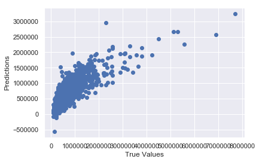

```python
## The line / model
plt.scatter(y_test, y_pred)
plt.xlabel("True Values")
plt.ylabel("Predictions")
```

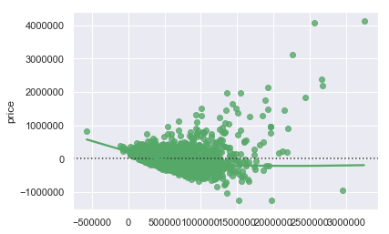

```python
sns.residplot(y_pred, y_test, lowess=True, color="g")
```

```python
print ("Score:", lm.score(X_test, y_test))
```

```
Score: 0.6464287941175522
```

```python
test_mae = metrics.mean_absolute_error(y_test, y_pred)
test_rmse = np.sqrt(metrics.mean_squared_error(y_test, y_pred))


print('Mean Absolute Error:' + str(metrics.mean_absolute_error(y_test, y_pred)))
print('Mean Squared Error:' + str(metrics.mean_squared_error(y_test, y_pred)))
print('Root Mean Squared Error:' + str(np.sqrt(metrics.mean_squared_error(y_test, y_pred))))
```

```
Mean Absolute Error:141526.9686029574
Mean Squared Error:60956257983.10983
Root Mean Squared Error:246893.21169912678
```

```python
print('Mean Absolute Error  Z:', test_mae/price_std )
print('Root Mean Squared Error Z:' , test_rmse/price_std)
```

```
Mean Absolute Error  Z: 0.38549845927752346
Root Mean Squared Error Z: 0.6725004686781932
```

### Comparing our Model's performance on training data versus test data.

```python
print('Training: ', int(train_rmse), "vs. Testing: ", int(test_rmse))
```

```
Training:  207971 vs. Testing:  246893
```

### Let's try with more features

```python
#import feature from sklearn to help us create  polynomial features
from sklearn.preprocessing import PolynomialFeatures

#instantiate this class
poly_2 = PolynomialFeatures(degree=2, interaction_only=False)
#fit and transform the data and create a  new dataframe
df_poly_2= pd.DataFrame(poly_2.fit_transform(features), columns=poly_2.get_feature_names(features.columns))
```

```python
pd.set_option('display.max_columns', 300)
```

```python
df_poly_2.head()
```

|  | 1 | bedrooms | bathrooms | sqft_living | sqft_lot | floors | waterfront | view | condition | grade | sqft_above | sqft_basement | yr_renovated | zipcode | sqft_living15 | sqft_lot15 | yr_old | bedrooms^2 | bedrooms bathrooms | bedrooms sqft_living | bedrooms sqft_lot | bedrooms floors | bedrooms waterfront | bedrooms view | bedrooms condition | bedrooms grade | bedrooms sqft_above | bedrooms sqft_basement | bedrooms yr_renovated | … |
| --- | --- | --- | --- | --- | --- | --- | --- | --- | --- | --- | --- | --- | --- | --- | --- | --- | --- | --- | --- | --- | --- | --- | --- | --- | --- | --- | --- | --- | --- | --- |
| 0 | 1.0 | 3.0 | 1.00 | 1180.0 | 5650.0 | 1.0 | 0.0 | 0.0 | 3.0 | 7.0 | 1180.0 | 0.0 | 0.0 | 98178.0 | 1340.0 | 5650.0 | 62.0 | 9.0 | 3.00 | 3540.0 | 16950.0 | 3.0 | 0.0 | 0.0 | 9.0 | 21.0 | 3540.0 | 0.0 | 0.0 | … |
| 1 | 1.0 | 3.0 | 2.25 | 2570.0 | 7242.0 | 2.0 | 0.0 | 0.0 | 3.0 | 7.0 | 2170.0 | 400.0 | 1991.0 | 98125.0 | 1690.0 | 7639.0 | 66.0 | 9.0 | 6.75 | 7710.0 | 21726.0 | 6.0 | 0.0 | 0.0 | 9.0 | 21.0 | 6510.0 | 1200.0 | 5973.0 | … |
| 2 | 1.0 | 2.0 | 1.00 | 770.0 | 10000.0 | 1.0 | 0.0 | 0.0 | 3.0 | 6.0 | 770.0 | 0.0 | 0.0 | 98028.0 | 2720.0 | 8062.0 | 84.0 | 4.0 | 2.00 | 1540.0 | 20000.0 | 2.0 | 0.0 | 0.0 | 6.0 | 12.0 | 1540.0 | 0.0 | 0.0 | … |
| 3 | 1.0 | 4.0 | 3.00 | 1960.0 | 5000.0 | 1.0 | 0.0 | 0.0 | 5.0 | 7.0 | 1050.0 | 910.0 | 0.0 | 98136.0 | 1360.0 | 5000.0 | 52.0 | 16.0 | 12.00 | 7840.0 | 20000.0 | 4.0 | 0.0 | 0.0 | 20.0 | 28.0 | 4200.0 | 3640.0 | 0.0 | … |
| 4 | 1.0 | 3.0 | 2.00 | 1680.0 | 8080.0 | 1.0 | 0.0 | 0.0 | 3.0 | 8.0 | 1680.0 | 0.0 | 0.0 | 98074.0 | 1800.0 | 7503.0 | 30.0 | 9.0 | 6.00 | 5040.0 | 24240.0 | 3.0 | 0.0 | 0.0 | 9.0 | 24.0 | 5040.0 | 0.0 | 0.0 | … |

```python
X2_train, X2_test, y2_train, y2_test = train_test_split(df_poly_2, target, random_state=34,test_size=0.2)
print(X2_train.shape, y2_train.shape)
print(X2_test.shape, y2_test.shape)
```

```
(17290, 153) (17290,)
(4323, 153) (4323,)
```

```python
lm2 = linear_model.LinearRegression()
model2 = lm2.fit(X2_train, y2_train)
y2_train_pred = lm2.predict(X2_train)
```

```python
train2_mae = metrics.mean_absolute_error(y2_train, y2_train_pred)
```

```python
y2_pred = lm2.predict(X2_test)
# sns.residplot(y2_pred, y2_test, lowess=True, color="g")

test2_mae = metrics.mean_absolute_error(y2_test, y2_pred)

print("Training Error: ", train2_mae, "vs. Testing Error: ", test2_mae)
```

```
Training Error:  119938.43079207439 vs. Testing Error:  123376.26420092401
```

Now lets try and add on even more variables!

```python
poly = PolynomialFeatures(degree=3, interaction_only= False )
```

```python
df_poly_3= pd.DataFrame(poly.fit_transform(features), columns=poly.get_feature_names(features.columns))
df_poly_3.head()
```

|  | 1 | bedrooms | bathrooms | sqft_living | sqft_lot | floors | waterfront | view | condition | grade | sqft_above | sqft_basement | yr_renovated | zipcode | sqft_living15 | sqft_lot15 | yr_old | bedrooms^2 | bedrooms bathrooms | bedrooms sqft_living | bedrooms sqft_lot | bedrooms floors | bedrooms waterfront | bedrooms view | bedrooms condition | bedrooms grade | bedrooms sqft_above | bedrooms sqft_basement | bedrooms yr_renovated | … |
| --- | --- | --- | --- | --- | --- | --- | --- | --- | --- | --- | --- | --- | --- | --- | --- | --- | --- | --- | --- | --- | --- | --- | --- | --- | --- | --- | --- | --- | --- | --- |
| 0 | 1.0 | 3.0 | 1.00 | 1180.0 | 5650.0 | 1.0 | 0.0 | 0.0 | 3.0 | 7.0 | 1180.0 | 0.0 | 0.0 | 98178.0 | 1340.0 | 5650.0 | 62.0 | 9.0 | 3.00 | 3540.0 | 16950.0 | 3.0 | 0.0 | 0.0 | 9.0 | 21.0 | 3540.0 | 0.0 | 0.0 | … |
| 1 | 1.0 | 3.0 | 2.25 | 2570.0 | 7242.0 | 2.0 | 0.0 | 0.0 | 3.0 | 7.0 | 2170.0 | 400.0 | 1991.0 | 98125.0 | 1690.0 | 7639.0 | 66.0 | 9.0 | 6.75 | 7710.0 | 21726.0 | 6.0 | 0.0 | 0.0 | 9.0 | 21.0 | 6510.0 | 1200.0 | 5973.0 | … |
| 2 | 1.0 | 2.0 | 1.00 | 770.0 | 10000.0 | 1.0 | 0.0 | 0.0 | 3.0 | 6.0 | 770.0 | 0.0 | 0.0 | 98028.0 | 2720.0 | 8062.0 | 84.0 | 4.0 | 2.00 | 1540.0 | 20000.0 | 2.0 | 0.0 | 0.0 | 6.0 | 12.0 | 1540.0 | 0.0 | 0.0 | … |
| 3 | 1.0 | 4.0 | 3.00 | 1960.0 | 5000.0 | 1.0 | 0.0 | 0.0 | 5.0 | 7.0 | 1050.0 | 910.0 | 0.0 | 98136.0 | 1360.0 | 5000.0 | 52.0 | 16.0 | 12.00 | 7840.0 | 20000.0 | 4.0 | 0.0 | 0.0 | 20.0 | 28.0 | 4200.0 | 3640.0 | 0.0 | … |
| 4 | 1.0 | 3.0 | 2.00 | 1680.0 | 8080.0 | 1.0 | 0.0 | 0.0 | 3.0 | 8.0 | 1680.0 | 0.0 | 0.0 | 98074.0 | 1800.0 | 7503.0 | 30.0 | 9.0 | 6.00 | 5040.0 | 24240.0 | 3.0 | 0.0 | 0.0 | 9.0 | 24.0 | 5040.0 | 0.0 | 0.0 | … |

5 rows × 969 columns

```python
df_poly_3.head()
```

|  | 1 | bedrooms | bathrooms | sqft_living | sqft_lot | floors | waterfront | view | condition | grade | sqft_above | sqft_basement | yr_renovated | zipcode | sqft_living15 | sqft_lot15 | yr_old | bedrooms^2 | bedrooms bathrooms | bedrooms sqft_living | bedrooms sqft_lot | bedrooms floors | bedrooms waterfront | bedrooms view | bedrooms condition | bedrooms grade | bedrooms sqft_above | bedrooms sqft_basement | bedrooms yr_renovated | … |
| --- | --- | --- | --- | --- | --- | --- | --- | --- | --- | --- | --- | --- | --- | --- | --- | --- | --- | --- | --- | --- | --- | --- | --- | --- | --- | --- | --- | --- | --- | --- |
| 0 | 1.0 | 3.0 | 1.00 | 1180.0 | 5650.0 | 1.0 | 0.0 | 0.0 | 3.0 | 7.0 | 1180.0 | 0.0 | 0.0 | 98178.0 | 1340.0 | 5650.0 | 62.0 | 9.0 | 3.00 | 3540.0 | 16950.0 | 3.0 | 0.0 | 0.0 | 9.0 | 21.0 | 3540.0 | 0.0 | 0.0 | … |
| 1 | 1.0 | 3.0 | 2.25 | 2570.0 | 7242.0 | 2.0 | 0.0 | 0.0 | 3.0 | 7.0 | 2170.0 | 400.0 | 1991.0 | 98125.0 | 1690.0 | 7639.0 | 66.0 | 9.0 | 6.75 | 7710.0 | 21726.0 | 6.0 | 0.0 | 0.0 | 9.0 | 21.0 | 6510.0 | 1200.0 | 5973.0 | … |
| 2 | 1.0 | 2.0 | 1.00 | 770.0 | 10000.0 | 1.0 | 0.0 | 0.0 | 3.0 | 6.0 | 770.0 | 0.0 | 0.0 | 98028.0 | 2720.0 | 8062.0 | 84.0 | 4.0 | 2.00 | 1540.0 | 20000.0 | 2.0 | 0.0 | 0.0 | 6.0 | 12.0 | 1540.0 | 0.0 | 0.0 | … |
| 3 | 1.0 | 4.0 | 3.00 | 1960.0 | 5000.0 | 1.0 | 0.0 | 0.0 | 5.0 | 7.0 | 1050.0 | 910.0 | 0.0 | 98136.0 | 1360.0 | 5000.0 | 52.0 | 16.0 | 12.00 | 7840.0 | 20000.0 | 4.0 | 0.0 | 0.0 | 20.0 | 28.0 | 4200.0 | 3640.0 | 0.0 | … |
| 4 | 1.0 | 3.0 | 2.00 | 1680.0 | 8080.0 | 1.0 | 0.0 | 0.0 | 3.0 | 8.0 | 1680.0 | 0.0 | 0.0 | 98074.0 | 1800.0 | 7503.0 | 30.0 | 9.0 | 6.00 | 5040.0 | 24240.0 | 3.0 | 0.0 | 0.0 | 9.0 | 24.0 | 5040.0 | 0.0 | 0.0 | … |

5 rows × 969 columns

```python
X_train3, X_test3, y_train3, y_test3 = train_test_split(df_poly_3, target, random_state=34,test_size=0.2)
print(X_train.shape, y_train.shape)
print(X_test.shape, y_test.shape)
```

```
(17290, 16) (17290,)
(4323, 16) (4323,)
```

```python
# fit a model
lm3 = linear_model.LinearRegression()
lm3 = lm.fit(X_train3, y_train3)
```

```python
y_train_pred3 = lm3.predict(X_train3)
```

```python
train_mae3 = metrics.mean_absolute_error(y_train3, y_train_pred3)

print('Mean Absolute Error:' + str(metrics.mean_absolute_error(y_train3, y_train_pred3)))
print('Mean Squared Error:' + str(metrics.mean_squared_error(y_train3, y_train_pred3)))
print('SqRt of Mean Squared Error:' + str(np.sqrt(metrics.mean_squared_error(y_train3, y_train_pred3))))
```

```
Mean Absolute Error:115819.11331252655
Mean Squared Error:27661761596.599915
SqRt of Mean Squared Error:166318.2539488673
```

```python
y_pred3 = lm.predict(X_test3)
```

```python
test_mae3 = metrics.mean_absolute_error(y_test3, y_pred3)
print('Mean Absolute Error:' + str(metrics.mean_absolute_error(y_test3, y_pred3)))
print('Mean Squared Error:' + str(metrics.mean_squared_error(y_test3, y_pred3)))
print('SqRt of Mean Squared Error:' + str(np.sqrt(metrics.mean_squared_error(y_test3, y_pred3))))
```

```
Mean Absolute Error:130149.22259374915
Mean Squared Error:46716361237.61557
SqRt of Mean Squared Error:216139.6799239223
```

### Comparing our Training Error and Test Error across models

```python
errors = [[train_mae, test_mae],
[ train2_mae, test2_mae],
[ train_mae3, test_mae3]]
```

```python
df_error = pd.DataFrame(errors,index=[1,2,3],  columns=['train_error', 'test_error'])
```

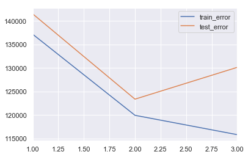

```python
df_error.plot.line()
```